# **Capstone project: Providing data-driven suggestions for HR**

```python
# Logistic Regression model results for the validation data

# Generate predictions on X_val
y_preds = model.predict(X_val)
```

```python
# Score the model on its accuracy with the validation data
model.score(X_val, y_val)
```

```
0.926829268292683
```

```python
# Obtain a confusion matrix

cm = confusion_matrix(y_val, y_preds)
```

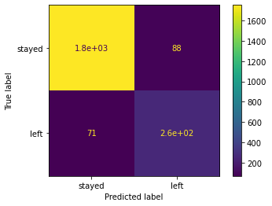

```python
# Display the confusion matrix

disp = ConfusionMatrixDisplay(confusion_matrix=cm,
                              display_labels=['stayed', 'left'],
                              )
disp.plot();
```

```python
# Create a classification report
target_labels = ['stayed', 'left']
print(classification_report(y_val, y_preds, target_names=target_labels))
```

```
              precision    recall  f1-score   support

      stayed       0.96      0.95      0.96      1839
        left       0.75      0.79      0.77       334

    accuracy                           0.93      2173
   macro avg       0.86      0.87      0.86      2173
weighted avg       0.93      0.93      0.93      2173
```

```python
accuracy = accuracy_score(y_val, y_preds)
precision = precision_score(y_val, y_preds)
recall = recall_score(y_val, y_preds)
f1 = f1_score(y_val, y_preds)
```

```python
# Create table of results

results = pd.DataFrame(columns=['Model', 'Accuracy','Precision',
                                'Recall', 'F1-Score'])

print(results)
```

```
Empty DataFrame
Columns: [Model, Accuracy, Precision, Recall, F1-Score]
Index: []
```

```python
# record results from the logistic regression model

log_reg_list = ['Logistic Regression Val', accuracy, precision, recall, f1]

results.loc[len(results)] = log_reg_list
print(results)
```

```
                     Model  Accuracy  Precision    Recall  F1-Score
0  Logistic Regression Val  0.926829   0.749288  0.787425  0.767883
```

```python
# This model is excellent at identifying employees who will stay with the company.
# It is not as effective at identifying employees who will leave the company.
# Having more training data may have been able to improve this score.
# Overall, it has an excellent accuracy score and good precision, recall and f1 scores
```

```python
# 2) Random Forest Model
```

```python
# The df is ready for modelling, as tree based models can handle multicollinearity
# The df is unbalanced with the target variable but not so much it needs any class rebalancing.

# Isolate X variables

X = df.drop(columns=['left'])

# Isolate Y variable

y = df['left']
```

```python
# Split df into train and test data

X_tr, X_test, y_tr, y_test = train_test_split(X, y, stratify=y,
                                              test_size=0.2, random_state=42)
```

```python
# Split into train and validate sets

X_train, X_val, y_train, y_val = train_test_split(X_tr, y_tr, stratify=y_tr,
                                                  test_size=0.25, random_state=42)
```

```python
# Check the number of samples in each set

for x in [X_train, X_val, X_test]:
    print(len(x))
```

```
7194
2398
2399
```

```python
# Instantiate the random forest classifier
rf = RandomForestClassifier(random_state=42)

# Create a dictionary of hyperparameters to tune
cv_params = {'max_depth': [5, 10],
             'max_features': [1.0],
             'max_samples': [0.5, 0.8],
             'min_samples_leaf': [2, 5],
             'min_samples_split': [2, 5],
             'n_estimators': [100, 300],
             }

# Define a list of scoring metrics to capture
scoring = ['accuracy', 'precision', 'recall', 'f1']

# Instantiate the GridSearchCV object

rf_cv = GridSearchCV(rf, cv_params, scoring=scoring, cv=5, refit='recall')
```

```python
# Fit the model to the training data

rf_cv.fit(X_train, y_train)
```

```
GridSearchCV(cv=5, error_score=nan,
             estimator=RandomForestClassifier(bootstrap=True, ccp_alpha=0.0,
                                              class_weight=None,
                                              criterion='gini', max_depth=None,
                                              max_features='auto',
                                              max_leaf_nodes=None,
                                              max_samples=None,
                                              min_impurity_decrease=0.0,
                                              min_impurity_split=None,
                                              min_samples_leaf=1,
                                              min_samples_split=2,
                                              min_weight_fraction_leaf=0.0,
                                              n_estimators=100, n_jobs=None,
                                              oob_score=False, random_state=42,
                                              verbose=0, warm_start=False),
             iid='deprecated', n_jobs=None,
             param_grid={'max_depth': [5, 10], 'max_features': [1.0],
                         'max_samples': [0.5, 0.8], 'min_samples_leaf': [2, 5],
                         'min_samples_split': [2, 5],
                         'n_estimators': [100, 300]},
             pre_dispatch='2*n_jobs', refit='recall', return_train_score=False,
             scoring=['accuracy', 'precision', 'recall', 'f1'], verbose=0)
```

```python
# Find the best score across all validation folds

rf_cv.best_score_
```

```
0.9087866108786612
```

```python
# Examine best hyperparameter combination

rf_cv.best_params_
```

```
{'max_depth': 5,
 'max_features': 1.0,
 'max_samples': 0.8,
 'min_samples_leaf': 2,
 'min_samples_split': 2,
 'n_estimators': 300}
```

```python
# Use the random forest model to predict on the validation data

rf_val_preds = rf_cv.best_estimator_.predict(X_val)
```

```python
# Calculate scores for the random forest model on validation data

accuracy = accuracy_score(y_val, rf_val_preds)
precision = precision_score(y_val, rf_val_preds)
recall = recall_score(y_val, rf_val_preds)
f1 = f1_score(y_val, rf_val_preds)
```

```python
rf_val_list = ['Random Forest Val', accuracy, precision, recall, f1]

results.loc[len(results)] = rf_val_list
print(results)
```

```
                     Model  Accuracy  Precision    Recall  F1-Score
0  Logistic Regression Val  0.926829   0.749288  0.787425  0.767883
1        Random Forest Val  0.964554   0.868235  0.927136  0.896719
```

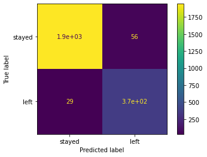

```python
# Generate array of values for confusion matrix
cm = confusion_matrix(y_val, rf_val_preds, labels=rf_cv.classes_)

# Plot confusion matrix
disp = ConfusionMatrixDisplay(confusion_matrix=cm,
                             display_labels=['stayed', 'left'])
disp.plot();
```

```python
# 3) XGBoost Model
```

```python
# Instantiate the XGBoost classifier
xgb = XGBClassifier(objective='binary:logistic', random_state=42)

# Create a dictionary of hyperparameters to tune
cv_params = {'max_depth': [5],
             'min_child_weight': [3],
             'learning_rate': [0.1],
             'n_estimators': [300]
             }

# Define a list of scoring metrics to capture
scoring = ['accuracy', 'precision', 'recall', 'f1']

# Instantiate the GridSearchCV object
xgb_cv = GridSearchCV(xgb, cv_params, scoring=scoring, cv=5, refit='recall')
```

```python
# Fit the model to the X_train and y_train data
```

```python
# xgb_cv.fit(X_train, y_train)
```

```python
# Examine best score
# xgb_cv.best_score_
```

```python
# Examine best parameters
# xgb_cv.best_params_
```

```python
# Use the XGB model to predict on the validation data

# xgb_val_preds = xgb_cv.best_estimator_.predict(X_val)
```

```python
# Generate array of values for confusion matrix
#cm = confusion_matrix(y_val, xgb_val_preds, labels=xgb_cv.classes_)

# Plot confusion matrix
#disp = ConfusionMatrixDisplay(confusion_matrix=cm,
#                             display_labels=['stayed', 'left'])
#disp.plot();
```

```python
# Calculate the scores for the XGBoost model on the validation data

#accuracy = accuracy_score(y_val, xgb_val_preds)
#precision = precision_score(y_val, xgb_val_preds)
#recall = recall_score(y_val, xgb_val_preds)
#f1 = f1_score(y_val, xgb_val_preds)
```

```python
# Add the scores to the results list

#xgb_val_list = ['XGBoost Val', accuracy, precision, recall, f1]

#results.loc[len(results)] = xgb_val_list
#print(results)
```

# pacE: Execute Stage

- Interpret model performance and results
- Share actionable steps with stakeholders

✏

## Recall evaluation metrics

- **AUC** is the area under the ROC curve; it's also considered the probability that the model ranks a random positive example more highly than a random negative example.
- **Precision** measures the proportion of data points predicted as True that are actually True, in other words, the proportion of positive predictions that are true positives.
- **Recall** measures the proportion of data points that are predicted as True, out of all the data points that are actually True. In other words, it measures the proportion of positives that are correctly classified.
- **Accuracy** measures the proportion of data points that are correctly classified.
- **F1-score** is an aggregation of precision and recall.

💭

### Reflect on these questions as you complete the executing stage.

- What key insights emerged from your model(s)?
- What business recommendations do you propose based on the models built?
- What potential recommendations would you make to your manager/company?
- Do you think your model could be improved? Why or why not? How?
- Given what you know about the data and the models you were using, what other questions could you address for the team?
- Do you have any ethical considerations in this stage?

1-3) The machine-learning model revealed significantly different insights than the exploratory data analysis. It would be beneficial for the company to keep both in mind when moving forward with implementing solutions to reducing employees leaving the company. The exploratory data analysis revealed the general profiles of employees most at risk of leaving the company and the sub-populations of employees who were likely to remain loyal to the company. Employees were more likely to leave the company when they had more than 6 projects and worked long monthly hours, particularly if they hadn't received a promotion within the last 5 years or weren't among the company's highest paid employees. This indicates the rate of employees leaving is being affected by burn out. This is a common issue across the workforce, so the HR department can turn towards other companies and examine what approaches have and have not been successful in the past to combat employee burnout. For example, the HR department could encourage a policy that employees have a max of 5 projects at a time. It also showed that employee departments have little to no correlation with employees leaving. This indicates the HR department can look to implement solutions more broadly rather than departmentally.

4) With additional data variables, engineered features, or adapting the parameters, it is possible that the model could be refined to improve its performance if the company should require that.

5) I expect I would get questions about how I chose the model I did, the chose of variables, and the most important features of the model.

There was a feature that was not important at all to the model- type of department, and I took it out of the model because using it would have resulted in 10 extra variables for this data after changing it to numerical values and the risk of overfitting the model was greater than the benefits of including it in the model.

The most important model features were projects, total hours, performance score, and hours per month. I would illustrate this using the bar graph data visualization.

6) Yes, I checked the potential impacts from all outcomes of the model (what happened if it predicted wrong) to consider if there were any ethical concerns of using the company using the model. I found that use of the model had minimal risks and potentially great benefits. When the model identifies a person as “left” and that is true, the employee may have interventions targeted towards them that will reduce the chance of them leaving, which may be beneficial to the employee and unlikely to cause them harm. When the model identifies a person as “left” and that is false, the employee was going to stay but is subject to interventions and improvements, which will likely improve their experience at the company and are unlikely to cause them harm. When the model identifies a person as “stayed” and that is true, the employee’s work life will probably go unchanged, though some of the interventions and improvements may also benefit all employees at the company. When the model identifies a person as “stayed” and that is false, the employee is not targeted for potential interventions they could benefit from and will likely leave the company, but this is the same fate as not having a model.

## Step 4. Results and Evaluation

- Interpret model
- Evaluate model performance using metrics
- Prepare results, visualizations, and actionable steps to share with stakeholders

```python
# Use the Champion Model: Random Forest Model to predict on the test data

rf_test_preds = rf_cv.best_estimator_.predict(X_test)
```

```python
# Calculate the scores for the Random Forest model on the test data

accuracy = accuracy_score(y_test, rf_test_preds)
precision = precision_score(y_test, rf_test_preds)
recall = recall_score(y_test, rf_test_preds)
f1 = f1_score(y_test, rf_test_preds)
```

```python
# Add the scores to the results list

rf_test_list = ['Random Forest Test', accuracy, precision, recall, f1]

results.loc[len(results)] = rf_test_list
print(results)
```

```
                     Model  Accuracy  Precision    Recall  F1-Score
0  Logistic Regression Val  0.926829   0.749288  0.787425  0.767883
1        Random Forest Val  0.964554   0.868235  0.927136  0.896719
2       Random Forest Test  0.968737   0.889157  0.927136  0.907749
```

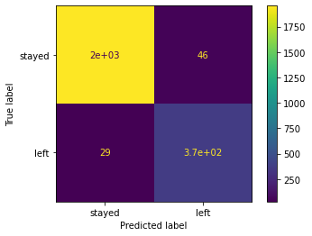

```python
# Generate array of values for confusion matrix
cm = confusion_matrix(y_test, rf_test_preds, labels=rf_cv.classes_)

# Plot confusion matrix
disp = ConfusionMatrixDisplay(confusion_matrix=cm,
                             display_labels=['stayed', 'left'])
disp.plot();
```

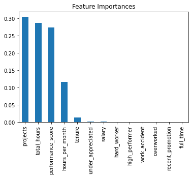

```python
importances = rf_cv.best_estimator_.feature_importances_

forest_importances = pd.Series(importances, index=X.columns).sort_values(ascending=False)

fig, ax = plt.subplots()
forest_importances.plot.bar(ax=ax);
plt.title("Feature Importances")
```

### Summary of model results

The scoring metric I am most interested in is recall, as this will find as many potential employees leaving the company as possible. I want to reduce false negatives (identifying people as staying when they will actaully leave). This is generally used in employee turnover models because it is generally more expensive to lose a trained employee than initiate some form of intervention. This model is successful across all metrics. The model performed identically on the test data as the validation data for recall, which is 0.927. This means that the model correctly identifies 92.7% of all people who leave the company. The F1 and precision scores increased for the model with the test data, but are within an expected variation. The accuracy score is 0.968, the precision score is 0.889, and the F1 score is 0.907. The model is excellent at predicting employees who are at risk of leaving the company and at predicting employees who will likely stay with the company. Since the model as well on the unseen test data as the validation data, which indicates the model is not overfitted to the training data, I am confident the company will be able to use this model on new data with successful results. The most important features for the model are projects, total hours worked for the company over an employee's entire employment there, and latest performance scores. Hours per month also contributed significantly. Tenure, being under appreciated, and salary level had a limited influence on the model. Being a hard worker, high performer, having a work accident, being overworked, having a recent promotion and being full time had no impact on the model.

### Conclusion, Recommendations, Next Steps

The machine-learning model revealed significantly different insights than the exploratory data analysis. It would be beneficial for the company to keep both in mind when moving forward with implementing solutions to reducing employees leaving the company. The exploratory data analysis revealed the general profiles of employees most at risk of leaving the company and the sub populations of employees who were likely to remain loyal to the company. Employees were more likely to leave the company when they had more than 6 projects and work long monthly hours, particularly if they hadn't received a promotion within the last 5 years or aren't among the company's highest paid employees. This indicates the rate of employees leaving is being affected by burn out. This is a common issue across the workforce, so the HR department can turn towards other companies and examine what approaches have and have not been successful in the past to combat employee burnout. For example, the HR department could encourage a policy that employees have a max of 5 projects at a time. It also showed that employee department has little to no correlation with employees leaving. This indicates the HR department can look to implement solutions more broadly rather than departmentally.

**Congratulations!** You've completed this lab. However, you may not notice a green check mark next to this item on Coursera's platform. Please continue your progress regardless of the check mark. Just click on the "save" icon at the top of this notebook to ensure your work has been logged.